# EDA: visualizing variation

The reference for these notes is

- r4ds section 7 ([Exploratory Data Analysis](http://r4ds.had.co.nz/exploratory-data-analysis.html))

Read in the UNC depts data

```r
library(tidyverse)
data <- read_csv(url("http://ryanthornburg.com/wp-content/uploads/2015/05/UNC_Salares_NandO_2015-05-06.csv"))
```

# Exploratory Data Analysis

Read [the introduction of the EDA chapter](http://r4ds.had.co.nz/exploratory-data-analysis.html#introduction-3) (note the definitions of of **variable**, **value**, **observation**, and **tabular data**.)

# Variation

How does one variable vary across the observations? Two things to keep an eye out for

- outlines
- modes

## summary statistics

Look at summary statistics of a variable. There are two types of summary statistics: location (mean, median, mode) and range/scale (min, max, variance).

```r
median(data$totalsal)
```

```
## [1] 59342
```

```r
max(data$totalsal)
```

```
## [1] 819069
```

A summary statistic compresses all $N$ observations you have into a single number. These numbers can be informative, but you lose information. Visualizing your data can often provide more insight that the summary statistics alone.

## point plot

For one variable the most simple visualization is to just plot the raw data.

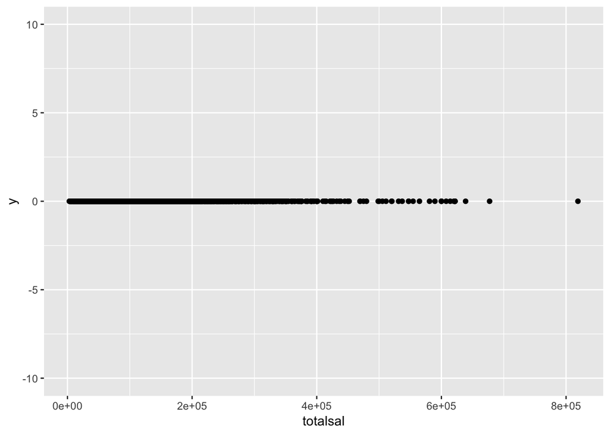

```r
# plot each data point
ggplot(data=data) +
    geom_point(aes(x=totalsal, y=0)) +
    ylim(-10, 10)
```

## jitter plot

One problem with the above plot is that data points lie on top of each other. A better version of this plot is a jitter plot

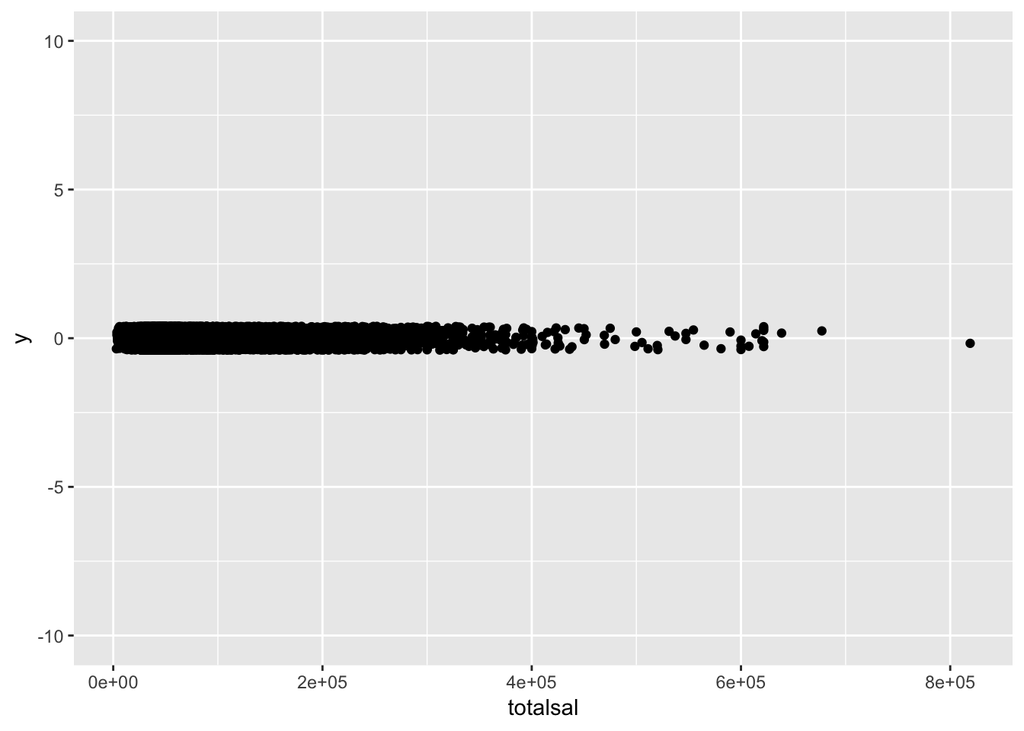

```r
# same plot as above but with random y values
ggplot(data=data) +
    geom_jitter(aes(x=totalsal, y=0)) +
    ylim(-10, 10)
```

A jitter plot adds a small amount of random noise to the data so the points no longer overlap.

## boxplot

A plot with all the data points has a lot of information in it. To gain insight it can be useful to compress the information. For example you might make a [box plot](https://en.wikipedia.org/wiki/Box_plot).

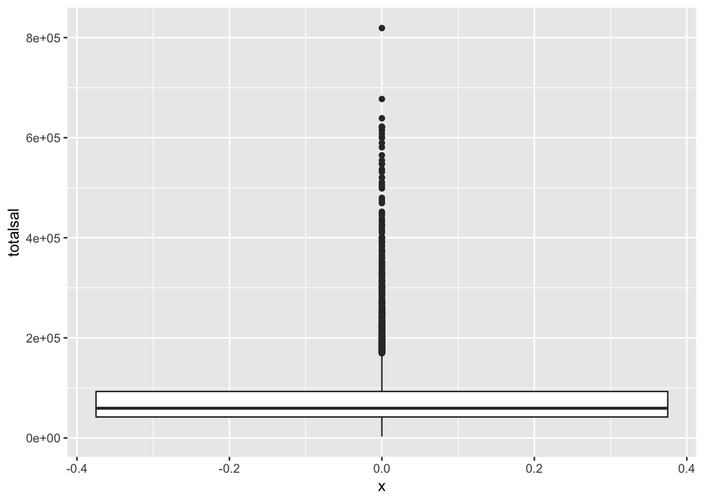

```r
ggplot(data=data) +
    geom_boxplot(aes(x=0, y=totalsal))
```

## histogram

Or a histogram

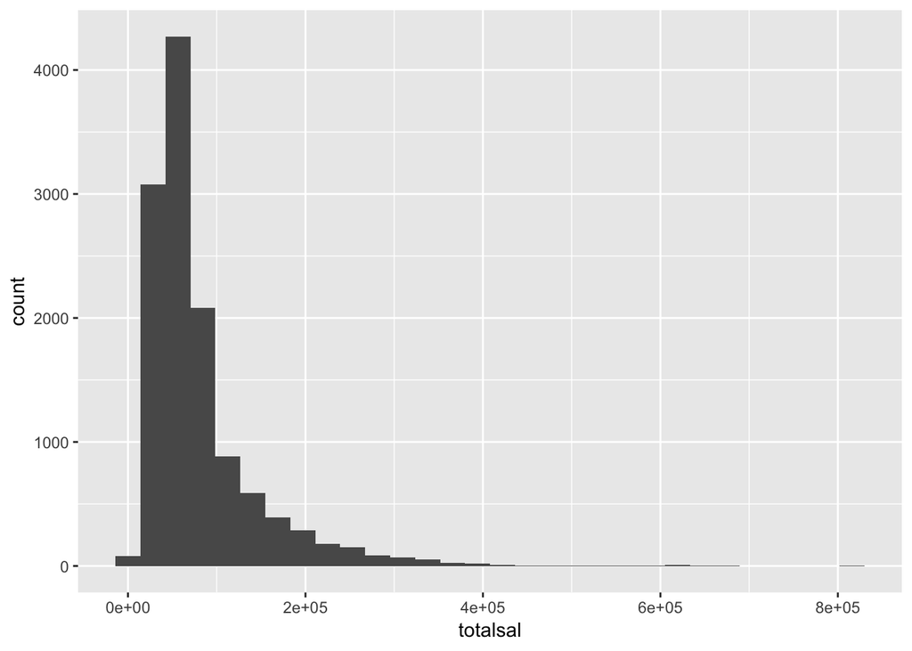

```r
ggplot(data=data) +
    geom_histogram(aes(x=totalsal), bins = 30)
```

## binwidth

Histograms have an important parameter: the bin width (or equivalently the number of bins). `ggplot2` defaults to 30 bins (divides the range of the data equally). **Warning: histograms can look dramatically different depending on the binwidth.** There is not necessarily one “correct” bin width. You should use a range of bin-widths and use your judgement.

This is probably too many bins

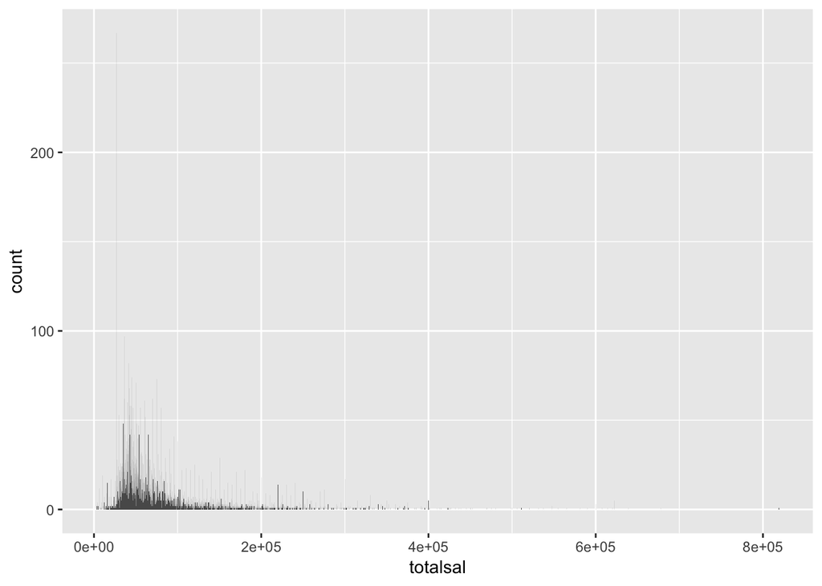

```r
ggplot(data=data) +
    geom_histogram(aes(x=totalsal), bins = 10000)
```

Probably too few bins

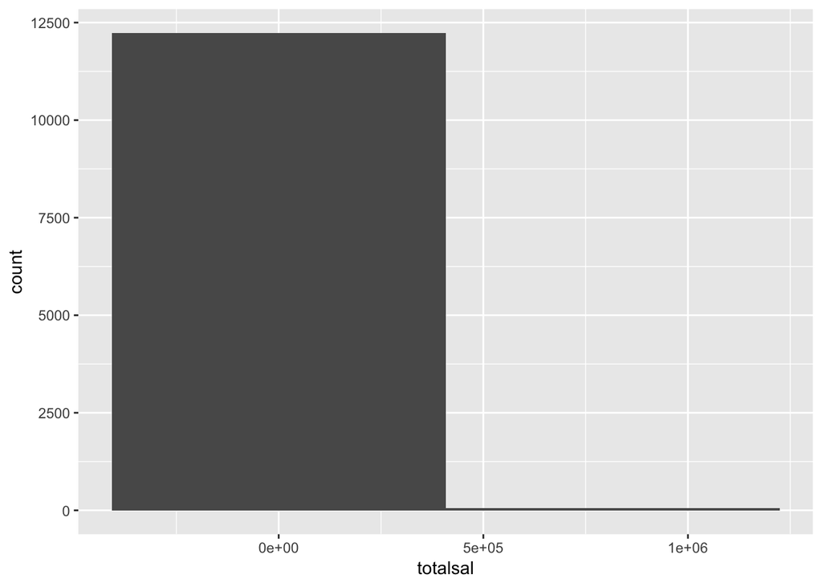

```r
ggplot(data=data) +
    geom_histogram(aes(x=totalsal), bins = 2)
```

A reasonable number of bins

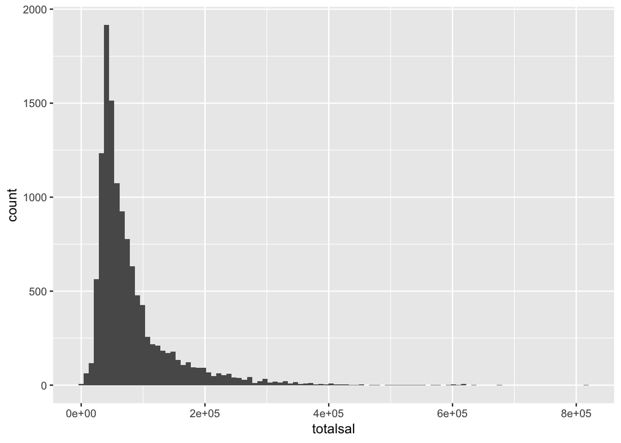

```r
ggplot(data=data) +
    geom_histogram(aes(x=totalsal), bins = 100)
```

Many data data are [multimodal](https://en.wikipedia.org/wiki/Multimodal_distribution). Finding modes can be some of the most important discoveries. Setting the bin-width too wide will miss modes. Setting the bin-width too small will show modes that don’t exist.

This simulated data has two modes. Depending on the bin-width you might see one, two, three (or more?) modes. “Objectively” answering: is that mode really there is non-trivial (e.g. see [SiZer](http://www.unc.edu/~marron/DataAnalyses/SiZer_Intro.html))

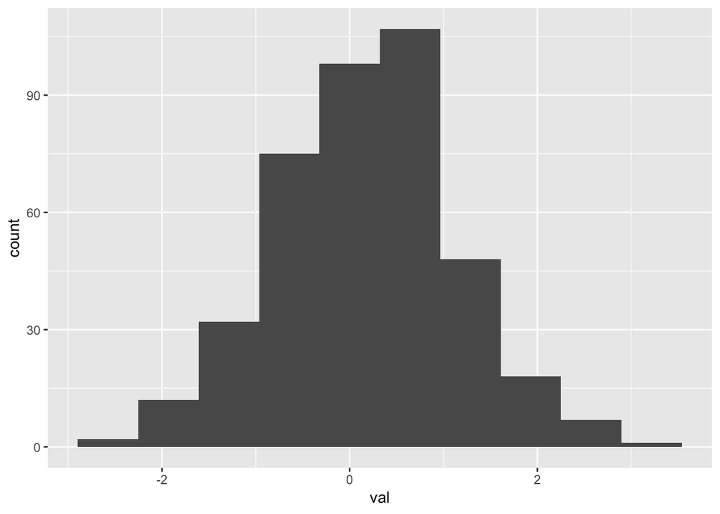

```r
set.seed(342)
mix <- tibble(val=c(rnorm(n=200, mean=0, sd=1),
                  rnorm(n=200, mean=.5, sd=1)))

# wide binwidth
ggplot(data=mix) +
    geom_histogram(aes(x=val), bins = 10)
```

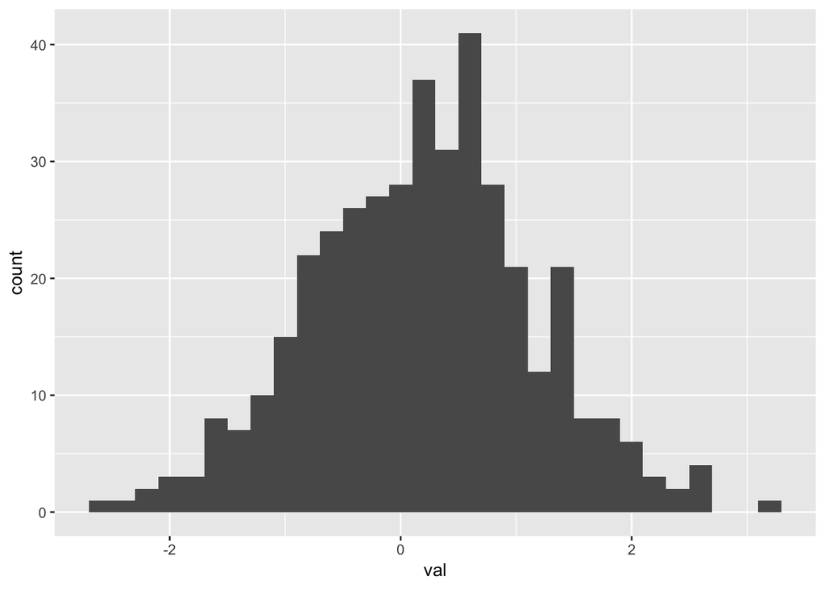

```r
# moderate binwidth
ggplot(data=mix) +
    geom_histogram(aes(x=val), bins = 30)
```

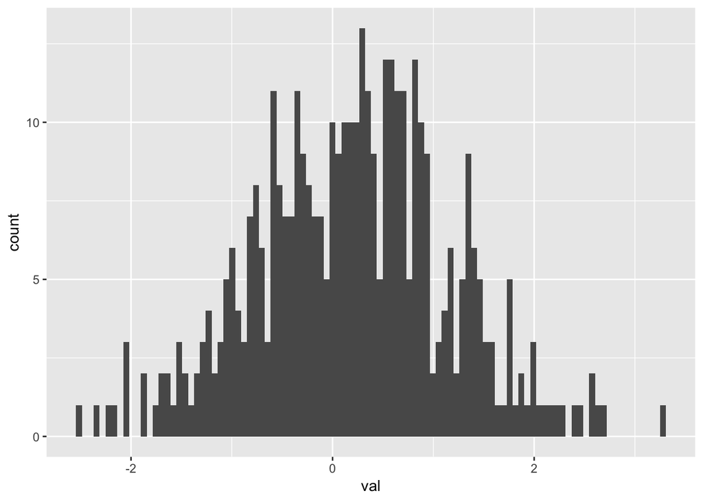

```r
# small binwidth
ggplot(data=mix) +
    geom_histogram(aes(x=val), bins = 100)
```

## kernel density estimate

A histogram reduces your N data points into a discrete distribution. A [Kernel Density Estimate](https://en.wikipedia.org/wiki/Kernel_density_estimation)(KDE) reduces your data to a continuous density.

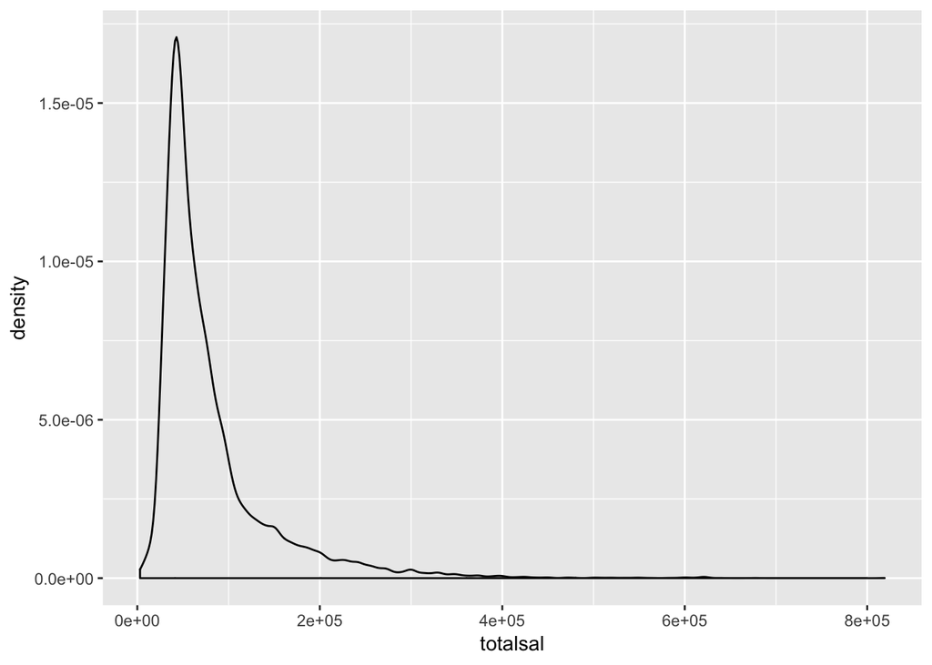

```r
# geom_density with its default values
ggplot(data=data) +
    geom_density(aes(x=totalsal), kernel="gaussian", adjust=1)
```

As with a histogram, a KDE as parameter(s) that control the level of data compression. You can read more about the details in the `geom_density` documentation or on Wikipedia. `ggplot` will use “smart defaults” but its worth playing around with this parameter. **Warning: always be wary of “smart defaults”. No one default value will work well in every (or even a majority of) situations.**

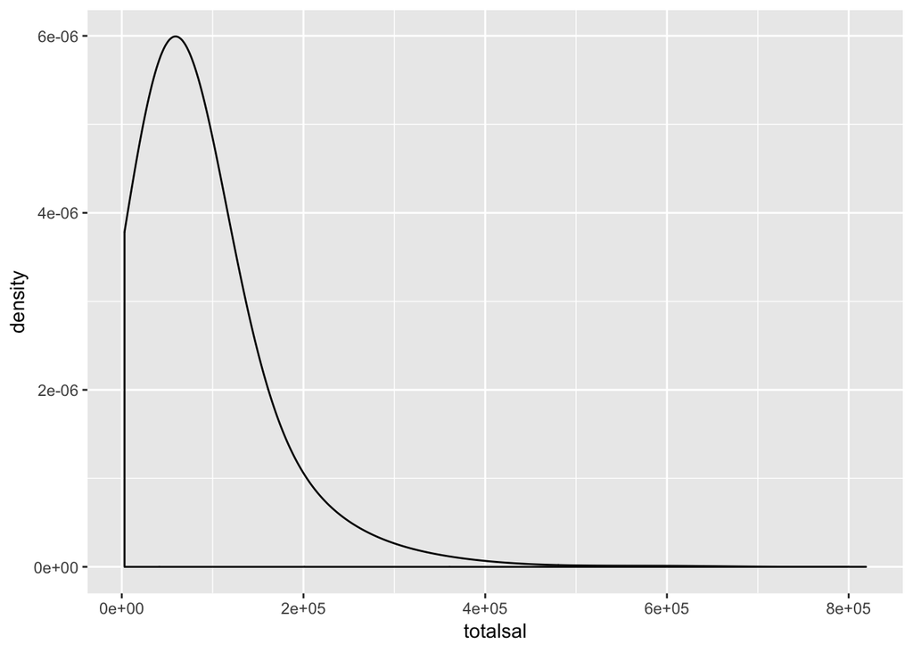

```r
# geom_density with a fat window
ggplot(data=data) +
    geom_density(aes(x=totalsal), kernel="gaussian", adjust=10)
```

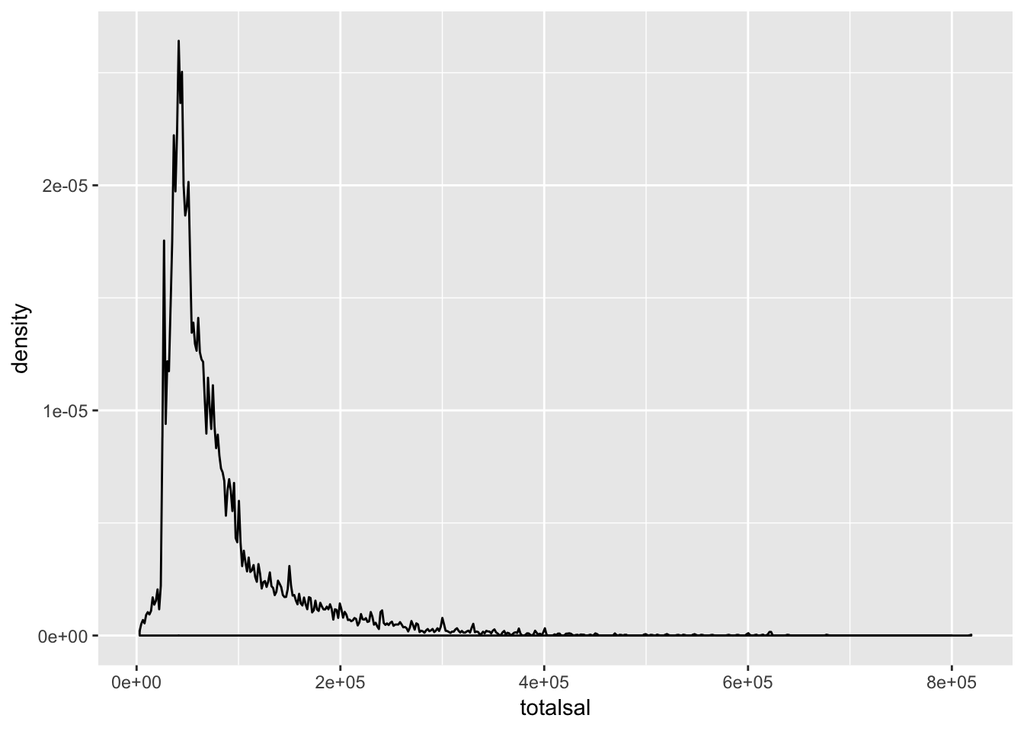

```r
# geom_density with a skinny window
ggplot(data=data) +
    geom_density(aes(x=totalsal), kernel="gaussian", adjust=.1)
```

## combining the plots

Best practice for exploratory analysis is to include the raw points with a histogram and/or KDE

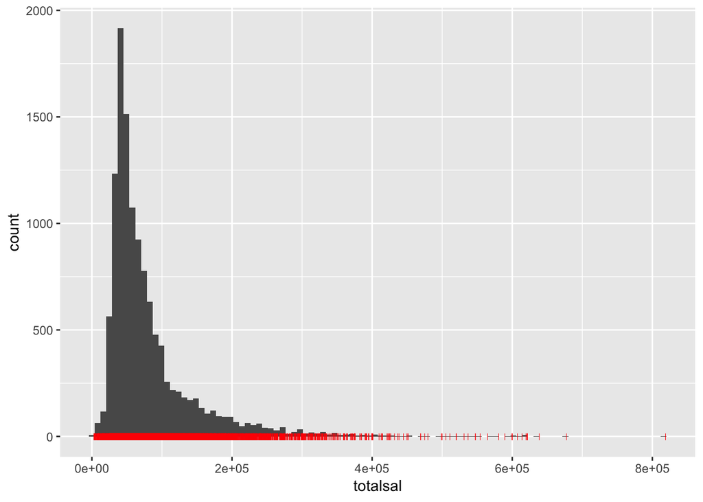

```r
ggplot(data=data) +
    geom_histogram(aes(x=totalsal), bins=100) +
    geom_point(aes(x=totalsal, y=0), shape='|', color='red') # use vertical points or jitter
```

# covariation

A few things to keep an eye out for

- is there a relationship
- outliers
- clusters

For covariation between two numerical variables [correlation](https://en.wikipedia.org/wiki/Pearson_correlation_coefficient) is the most simple measure of relationship

```r
cor(data$age, data$totalsal)
```

```
## [1] 0.2355144
```

and a scatter plot is the most simple visualization

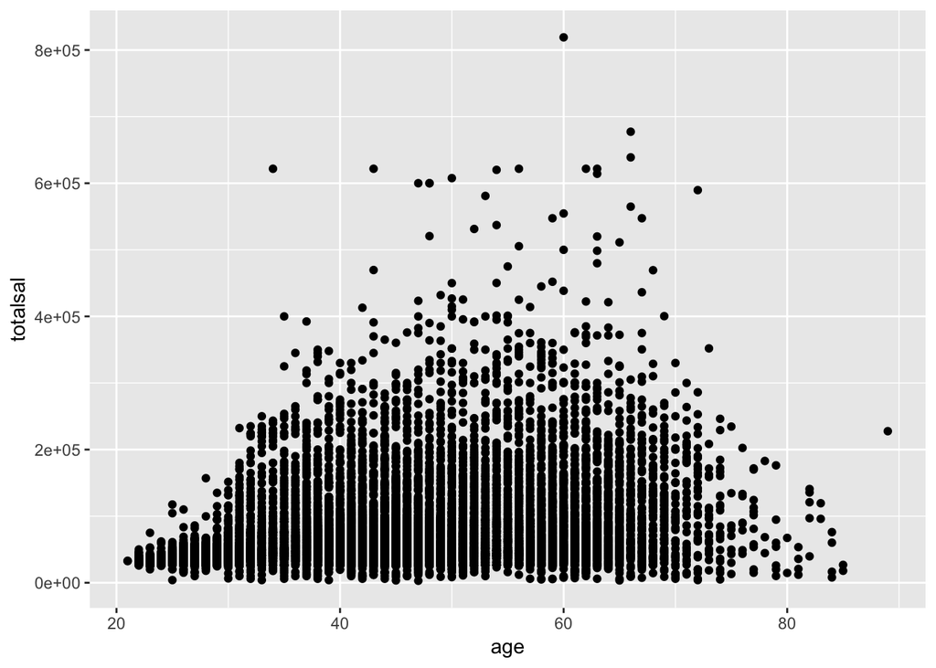

```r
ggplot(data=data) +
    geom_point(aes(x=age, y=totalsal))
```

Bar plots allow you to look at the relationship between a categorical variable and a continuous variable

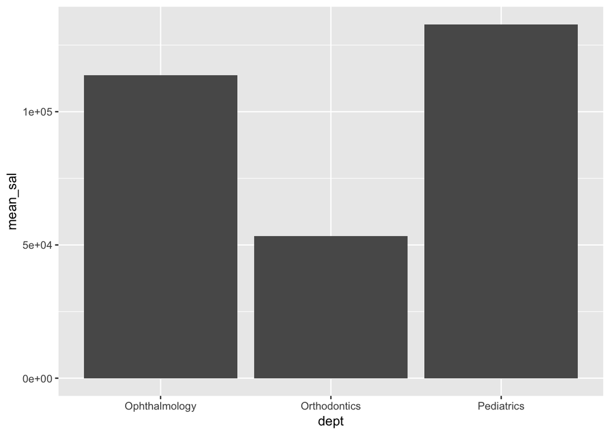

```r
data %>%
    filter(dept %in% c("Pediatrics", "Orthodontics" , 'Ophthalmology')) %>%
    group_by(dept) %>%
    summarise(mean_sal = mean(totalsal)) %>%
    ggplot() +
    geom_bar(aes(x=dept, y=mean_sal), stat='identity')
```

You or use a boxplot

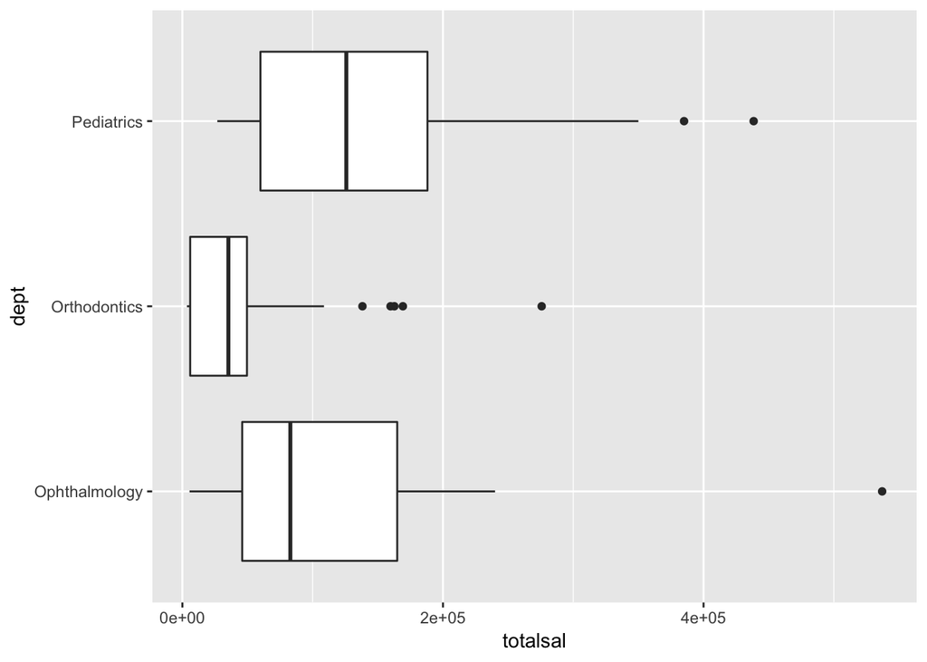

```r
data %>%
    filter(dept %in% c("Pediatrics", "Orthodontics" , 'Ophthalmology')) %>%
    ggplot() +
    geom_boxplot(aes(x=dept, y=totalsal)) +
    coord_flip() # max the labels horizontal so people can read them!
```

Clusters!

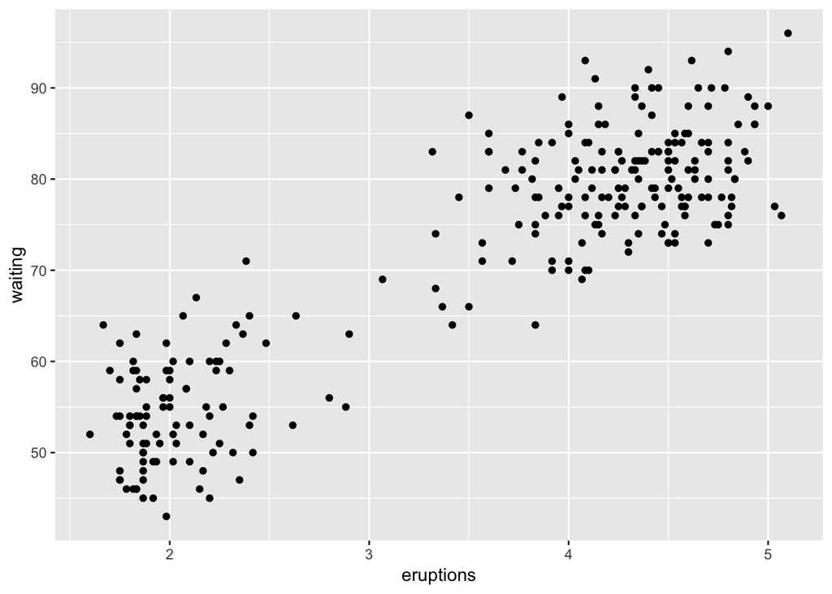

```r
ggplot(data = faithful) +
  geom_point(mapping = aes(x = eruptions, y = waiting))
```

# Covariation between three or more variables

Visualizing the relationships among three more variables becomes challenging. If you have three continuous variables you can make a 3d scatter plot, but these are typically not super useful

You can use additional aesthetic mappings such as color to a 2d scatter plot or shape

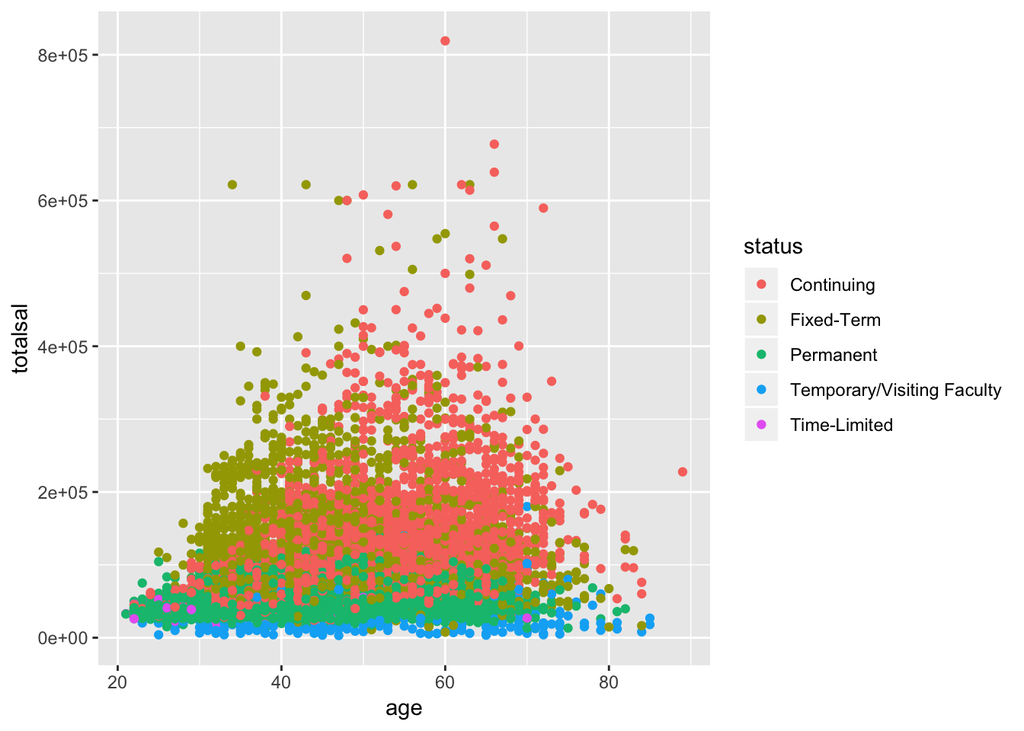

```r
ggplot(data=data) +
    geom_point(aes(x=age, y=totalsal, color=status))
```